# Tutorial - Nadal 2021

Toni Rodon

Universitat Pompeu Fabra  
toni.rodon@upf.edu – [www.tonirodon.cat](http://www.tonirodon.cat/)

En molts països és comú enviar o donar un targetó per a celebrar un esdeveniment. Aniversaris, comiats, naixements… i, lògicament, targetons de nadal! Si, enlloc de comprar la postal de nadal, voleu fer-la amb R (quelcom que de ben segur a molts de vosaltres us ha passat pel cap), aquí teniu un breu tutorial que us guia en com plantejar-ho.

El tutorial genera quatre *figures* i una postal. És qüestió de cada usuari decidir quina imatge vol triar per enviar a amics, coneguts, familiars i saludats.

## Arbre de nadal

Començarem fent un arbre de nadal. Aquesta part està basada en el codi que trobareu [aquí](https://rladies-baltimore.github.io/post/making-holiday-cards-in-r-2018/).

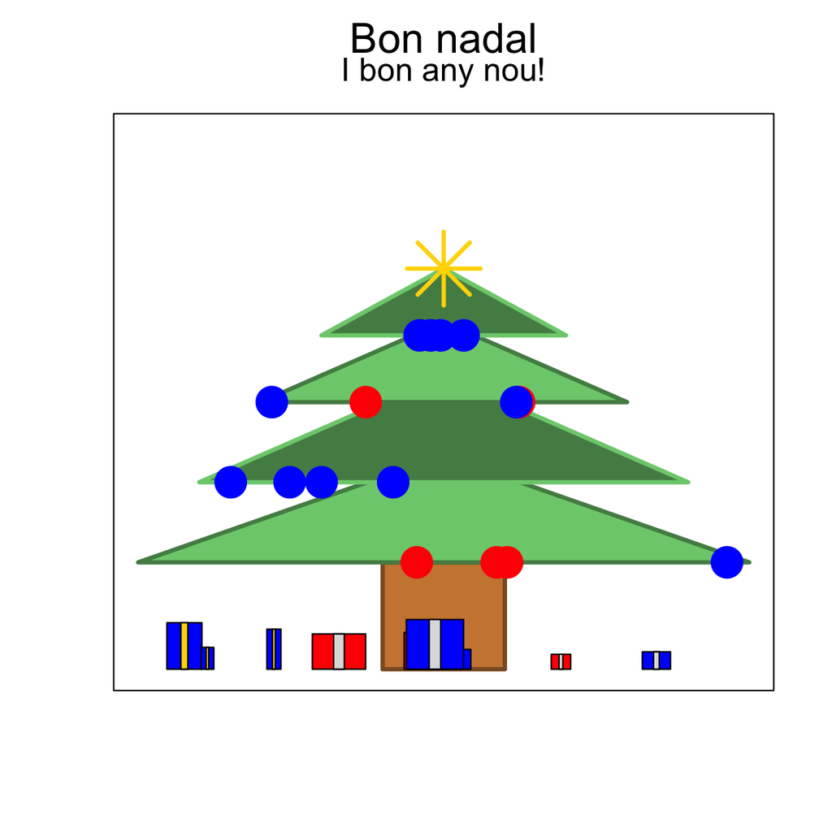

```r
# L'espai on dibuixarem l'arbre
plot(1:10,1:10,xlim=c(-5,5),ylim=c(0,10),type="n",xlab="",ylab="",xaxt="n",yaxt="n")
# Les banques i fulles
rect(-1,0,1,2,col="tan3",border="tan4",lwd=3)
polygon(c(-5,0,5),c(2,4,2),col="palegreen3",border="palegreen4",lwd=3)
polygon(c(-4,0,4),c(3.5,5.5,3.5),col="palegreen4",border="palegreen3",lwd=3)
polygon(c(-3,0,3),c(5,6.5,5),col="palegreen3",border="palegreen4",lwd=3)
polygon(c(-2,0,2),c(6.25,7.5,6.25),col="palegreen4",border="palegreen3",lwd=3)

#Afegir decoracions
points(x=runif(4,-5,5),y=rep(2,4),col=sample(c("blue","red"),size=4,replace=T),cex=3,pch=19)
points(x=runif(4,-4,4),y=rep(3.5,4),col=sample(c("blue","red"),size=4,replace=T),cex=3,pch=19)
points(x=runif(4,-3,3),y=rep(5,4),col=sample(c("blue","red"),size=4,replace=T),cex=3,pch=19)
points(x=runif(4,-2,2),y=rep(6.25,4),col=sample(c("blue","red"),size=4,replace=T),cex=3,pch=19)
points(0,7.5,pch=8,cex=5,col="gold",lwd=3)

#Afegir alguns regals i posar el títol
xPres = runif(10,-4.5,4.5)
xWidth = runif(10,0.1,0.5)
xHeight=runif(10,0,1)
for(i in 1:10){
  rect(xPres[i]-xWidth[i],0,xPres[i]+xWidth[i],xHeight[i],col=sample(c("blue","red"),size=1))
  rect(xPres[i]-0.2*xWidth[i],0,xPres[i]+0.2*xWidth[i],xHeight[i],col=sample(c("gold","grey87"),size=1))
}
mytitle = "Bon nadal"
mysubtitle = "I bon any nou!"
mtext(side=3, line=2,  cex=1.8, mytitle)
mtext(side=3, line=1, cex=1.4, mysubtitle)
```

```r
my_plot <- recordPlot()        # Ho gravem en un objecte per exportar
```

Un cop fet, l’exportarem en format *png*.

```r
png("arbre_nadal.png")
my_plot
dev.off()
```

## Arbre de nadal amb ggplot

Si sou fans de ggplot, podeu aprofitar les seves potencialitats per fer un arbre de nadal (aquest i el següent arbre estan inspirats en això d’[aquí](https://github.com/pbiecek/TechnikiWizualizacjiDanych2018/tree/master/PraceDomowe/PD8)).

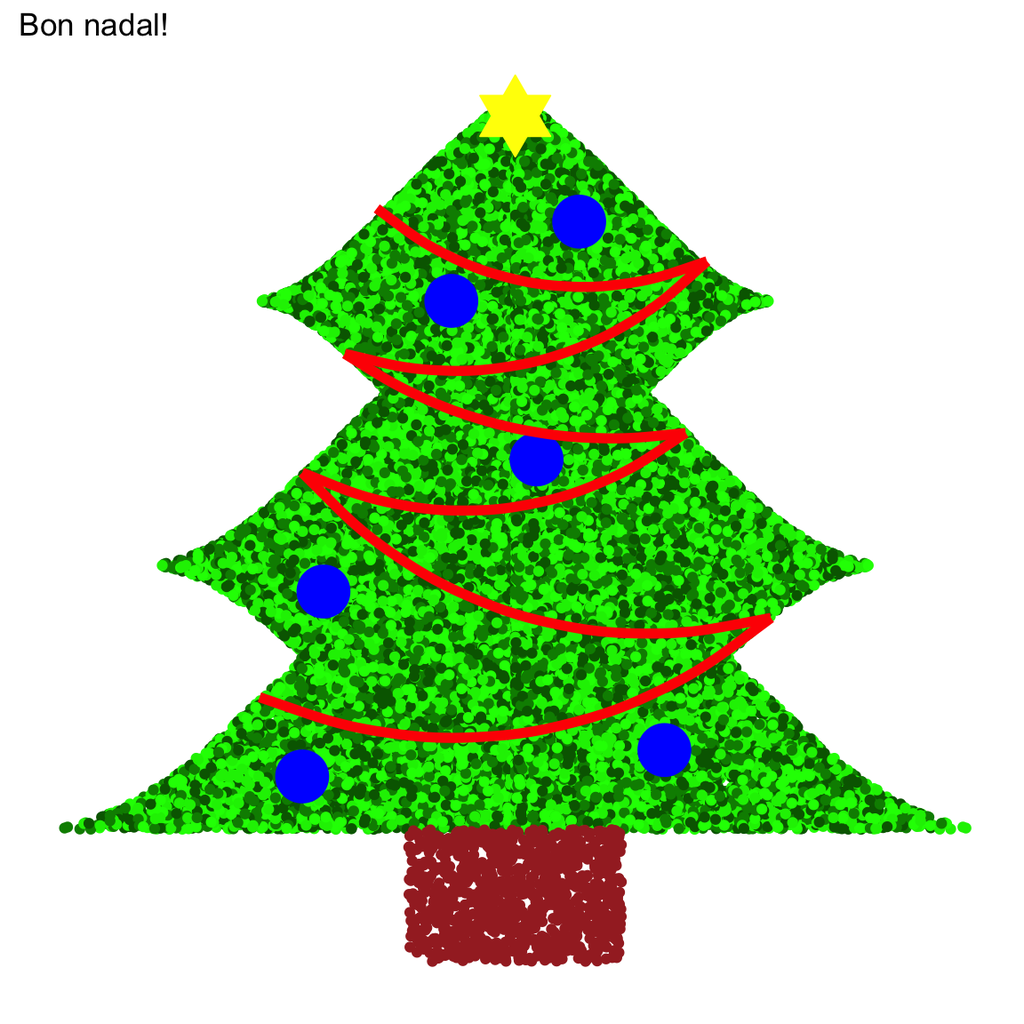

```r
library("ggplot2")

#Generem punts aleatoris

x1 <- runif(100000, -1, 1)
y1 <- runif(100000, -1, 1.6)

# equació pel cor de l'arbre
which1 <- x1^2+(y1-(x1^2)^(1/4))^2<=1
x1 <- x1[which1]
y1 <- y1[which1]

# segon nivell
x2 <- 1.5*x1 -1
y2 <- 1.5*y1

# tercer nivell
x3 <- 2*x1 -2
y3 <- 2*y1


dt <- data.frame(c(x1,x2,x3),c(y1,y2,y3))
colnames(dt) <- c("x", "y")
dt$y <- dt$y - 0.25
dt <- dt[dt$x>-2 & dt$x<1 & dt$y>-2.25 & dt$y<0,]
dt <- data.frame(c(dt$x,dt$x), c(dt$y, -dt$y))
colnames(dt) <- c("x", "y")

#soca

p1 <- runif(1000, -0.5, 0.5)
p2 <- runif(1000, -2.5, -2)

soca <- data.frame(p1,p2)

colors <- c('green', 'green2', 'green4', 'darkgreen')
colors2 <- rep(colors,length.out=dim(dt)[1])

bolesnadal <- data.frame(c(-1.8, -1.7, -1.1, -0.6, 0, 0.3), c(-1,0.7,-0.9,0.1,-0.3,0.3))
colnames(bolesnadal) <- c("x", "y")

cadena <- data.frame(data.frame(x1 = -0.5, x2 = 1, y1 = 21.0, y2 = 15.0))

estrella <- data.frame(c(0), c(0.7))
colnames(estrella)<- c("x", "y")

ggplot(data=NULL) + geom_point(data=dt, aes(x = y, y=x), col=colors2) +
  geom_point(data=bolesnadal, aes(x=y, y=x), size=10, col='blue') +
  geom_point (data=soca, aes(x=p1, y=p2), col='brown') +
  geom_point(data=estrella, aes(x=x, y=y),size=10,shape=24, col="yellow", fill='yellow') +
  geom_point(data=estrella, aes(x=x ,y=y),size=10,shape=25, col="yellow", fill='yellow') +
  geom_curve(aes(x=-1,xend=1.2,y=-0.65,yend=-1.2), col='red',size=2, curvature = 0.3) +
  geom_curve(aes(x=1.2, y=-1.2, xend=-1.2, yend=-1.5), size=2, col="red", curvature = -0.3) +
  geom_curve(aes(x=-1,xend=0.8,y=-0.65,yend=-0.5), col='red',size=2, curvature = 0.3) +
  geom_curve(aes(x=-0.8,xend=0.8,y=-0.2,yend=-0.5), col='red',size=2, curvature = 0.2) +
  geom_curve(aes(x=-0.8,xend=0.9,y=-0.2,yend=0.15), col='red',size=2, curvature = 0.3) +
  geom_curve(aes(x=-0.65,xend=0.9,y=0.35,yend=0.15), col='red',size=2, curvature = 0.3) +
  theme(axis.line=element_blank(),axis.text.x=element_blank(),
        axis.text.y=element_blank(),axis.ticks=element_blank(),
        axis.title.x=element_blank(),
        axis.title.y=element_blank(),legend.position="none",
        panel.background=element_blank(),panel.border=element_blank(),panel.grid.major=element_blank(),
        panel.grid.minor=element_blank(),plot.background=element_blank()) +
  ggtitle("Bon nadal!")
```

```r
ggsave("arbreggplot.png") #El gravem
```

## Arbre de nadal animat

Potser sou de crear felicitacions de nadal animades i enviar-los en format *gifs*. També ho podeu fer! El codi que teniu a continuació triga una mica. Paciència.

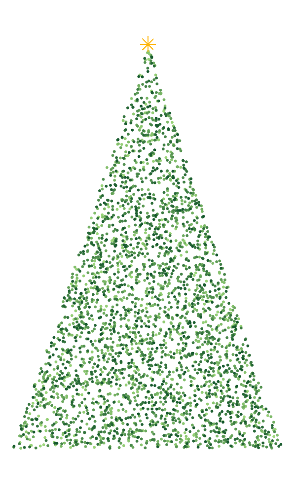

```r
library("ggplot2")
library("gganimate")
library("svglite")
library("dplyr")
HEIGTH <- 100

gen_data_v <- function(n_points, n_states) {


  id <- rep(1:n_points, each = n_states)
  time <- rep(1:n_states, times = n_points)

  velocity <- abs(rnorm(n_points, 1, 0.5))

  y1 <- runif(n_points, 0, HEIGTH)

  y <- as.vector(crossprod(t(0:(n_states-1)), -velocity) +
                   matrix(rep(y1, n_states), byrow = TRUE, n_states, n_points))
  y <- y %% HEIGTH

  x1 <- matrix(runif(n_points, 0, HEIGTH), 1, n_points)
  for(i in 2:n_states) {
    x1 <- rbind(x1, x1[i-1,] + rnorm(n_points, 0, 0.4))
  }

  x <- (as.vector(x1) %% HEIGTH) - 50

  data.frame(id, x, y, time)
}

dat <- gen_data_v(10000, 100)

x <- ggplot(data = dat, aes(x = x, y = y, color = id)) +
  geom_point(data = dat %>% filter(y < HEIGTH - 3*x & y < HEIGTH + 3 * x), size = 2) +
  geom_point(x=0, y=100, color = "#ffc20c", shape = 8, size = 10) +
  scale_color_gradient(low = "#addd8e", high = "#11673A", guide = FALSE) +
  theme_void() +
  coord_fixed() +
  transition_time(time) +
  ease_aes('linear')

y <- animate(x, renderer = magick_renderer(),width = 600, height = 1000)
y
```

```r
save_animation(y, "arbre_animat.gif") #El gravem
```

## Caganer

Finalment, farem un dels símbols del Nadal català per excel·lència: el caganer! El codi està basat (i lleugerament adaptat) de la llibreria *christmas*, que podeu trobar [aquí](https://cran.r-project.org/web/packages/christmas/index.html).

És un codi molt llarg, però està anotat perquè els diferents passos s’entenguin.

```r
#Preparem la finestra
newwindow <- function() {
  sc <- switch(Sys.info()[['sysname']],
               Windows = "windows",
               Linux  = "x11",
               Darwin = "quartz")
  eval(parse(text = paste(sc, "(width = 10, height = 7)", sep = "")))
}
#Funció per dibuixar el caganer
xmas2021caganer <- function(seed = NULL) {
  # "seed":
  if(!is.null(seed) & (is.na(seed) || !is(seed, "numeric")))
    stop("'seed' must be numeric or NULL")
  if (!is.null(seed)) set.seed(seed)

  t <- 0.8

  # Fons:
  newwindow()
  Sys.sleep(0.2 * t)
  u <- runif(2000, -6, 9)
  v <- runif(2000, -4, 10)
  plot(u, v, type = "n", xlim = c(-6, 9), ylim = c(-4, 10), asp = 1, axes = F, xlab = "", ylab = "")
  title(main = "", col.main = "forestgreen", cex.main = 1.5)
  polygon(c(-6, -6, 9, 9), c(-4, 1, 1, -4), border = NA, col = "azure2")
  polygon(c(-6, -6, 9, 9), c(1, 10, 10, 1), border = NA, col = "darkblue")
  lines(u[1:500], v[1:500], type = "p", pch = 8, lwd = 1, cex = 0.1, col = rainbow(180)[90])
  x <- seq(-6, 9, by = 0.01)
  lines(x, rnorm(length(x), 1, 0.05), type = "l", lwd = 3, col = "blue4")
  # El cos:
  Sys.sleep(t)
  a <- seq(0, 2 * pi, 0.05)
  x0 <-       cos(a)
  y0 <- 0.5 * sin(a)
  theta <- 75 * pi / 180
  x <- -0.3 + x0 * cos(theta) - y0 * sin(theta)
  y <-  0.5 + x0 * sin(theta) + y0 * cos(theta)
  polygon(x, y, border = NA, col = "white")
  # El cap:
  Sys.sleep(t)
  x <- 0.3 + 0.5 * cos(a)
  y <- 1.6 + 0.5 * sin(a)
  polygon(x, y, border = NA, col = "wheat3")
  # Nas:
  Sys.sleep(t)
  x <- 0.7 + 0.1 * cos(a)
  y <- 1.3 + 0.1 * sin(a)
  polygon(x, y, border = NA, col = "wheat3")
  # Ulls:
  Sys.sleep(t)
  x <- 0.6 + 0.05 * cos(a)
  y <- 1.5 + 0.05 * sin(a)
  polygon(x, y, border = NA, col = "black")
  x <- 0.7 + 0.05 * cos(a)
  y <- 1.5 + 0.05 * sin(a)
  polygon(x, y, border = NA, col = "black")
  # Bufanda:
  Sys.sleep(t)
  d <- seq(0, pi / 2)
  x <-       0.3 * cos(d)
  y <- 1.3 + 0.3 * sin(d)
  lines(x, y, lwd = 6)
  # Barretina:
  Sys.sleep(t)
  c <- seq(pi / 4, 5 * pi / 4, 0.05)
  x <- 0.10 + 0.77 * cos(c)
  y <- 1.65 + 0.52 * sin(c)
  polygon(x, y, border = NA, col = "red")
  polygon(c(-0.15, 0.75, 0.60, -0.25), c( 1.40, 1.90, 2.05,  1.50), border = NA, col = "black")
  # Cames:
  Sys.sleep(t)
  x0 <- 0.9 * cos(a)
  y0 <- 0.4 * sin(a)
  theta <- 30 * pi / 180
  x <- x0 * cos(theta) - y0 * sin(theta)
  y <- x0 * sin(theta) + y0 * cos(theta)
  polygon(x, y, col = "black")
  # Cul:
  Sys.sleep(t)
  x <- -0.55 + 0.35 * cos(a)
  y <- -0.34 + 0.35 * sin(a)
  polygon(x, y, border = NA, col = "wheat3")
  # Cames:
  Sys.sleep(t)
  x0 <-       cos(a)
  y0 <- 0.3 * sin(a)
  theta <- 70 * pi / 180
  x <-  0.42 + x0 * cos(theta) - y0 * sin(theta)
  y <- -0.45 + x0 * sin(theta) + y0 * cos(theta)
  polygon(x, y, col = "black")
  # ...més cames:
  Sys.sleep(t)
  b <- seq(0.98 * pi, 1.37 * pi, 0.05)
  x <- 0.65 * cos(b)
  y <- 0.65 * sin(b)
  polygon(x, y, border = NA, col = "black")
  # Peus:
  Sys.sleep(t)
  x <-  0.4 + 0.50 * cos(a)
  y <- -1.3 + 0.15 * sin(a)
  polygon(x, y, border = NA, col = "tan4")
  # Cinturó:
  Sys.sleep(t)
  polygon(c(-0.85, 0.25, 0.25, -0.85), c(-0.20, 0.50, 0.70,  0.15), border = "NA", col = "red")
  # ...Més cames:
  Sys.sleep(t)
  polygon(c(-0.31, 0.27, 0.25, -0.60), c(-0.61, 0.22, 0.50, -0.05), border = "NA", col = "black")
  # Braços:
  Sys.sleep(t)
  polygon(c(0.10, -0.25, -0.6, -0.3), c(0.25,  0.10,  0.5,  0.9), border = "NA", col = "white")
  polygon(c(0, -0.05, -0.30, 0.10), c(0, -0.10,  0.15, 0.28), border = "NA", col = "white")
  x <- 0.50 + 0.2 * cos(a)
  y <- 0.08 + 0.2 * sin(a)
  Sys.sleep(t)
  polygon(x, y, border = NA, col = "wheat3")
  polygon(c(-0.05, 0.08, 0.40,  0.40), c(-0.10, 0.28, 0.28, -0.10), border = "NA", col = "white")
  # Ca...:
  Sys.sleep(t)
  x <- -0.5 + 0.30 * cos(a)
  y <- -1.3 + 0.15 * sin(a)
  polygon(x, y, border = NA, col = "darkorange4")
  # ...ga...:
  Sys.sleep(t)
  x <- -0.50 + 0.2 * cos(a)
  y <- -1.15 + 0.1 * sin(a)
  polygon(x, y, border = NA, col = "darkorange4")
  # ...rada:
  Sys.sleep(t)
  x0 <- 0.13 * cos(a)
  y0 <- 0.07 * sin(a)
  theta <- 70
  x <- -0.5 + x0 * cos(theta * pi / 180) - y0 * sin(theta * pi / 180)
  y <- -1.0 + x0 * sin(theta * pi / 180) + y0 * cos(theta * pi / 180)
  polygon(x, y, border = NA, col = "darkorange4")
  # Tronc:
  Sys.sleep(t)
  x <- c(-2.4, -1.6, -1.6, -2.4) + rnorm(4, 0, 0.02)
  y <- c( 2.5,  2.5, -1.2, -1.2) + rnorm(4, 0, 0.02)
  polygon(x, y, border = NA, col = "brown")
  x <- runif(9, -2.3, -1.7)
  y <- runif(9, -0.5,  2.2)
  lines(x, y, type = "p", pch = "|", cex = 1.4, col = "orangered4")
  x <- seq(-2.4, -1.6, by = 0.01)
  lines(x, rnorm(length(x), -1.2, 0.05), col = "azure2")
  Sys.sleep(t)
  # Arbre 1:
  x <- c(-5.0, 1.0, -2)
  y <- c( 2.5, 2.5,  6)
  polygon(x, y, border = NA, col = "forestgreen")
  t <- seq(0, 1, by = 0.01)
  x <- -5 + 6 * t
  y <-  6 - 7 * abs(t - 0.5)
  y <- y + rnorm(length(y), 0, 0.05)
  lines(x, y, col = "forestgreen", lwd = 6)
  lines(x, rnorm(length(x), 2.7, 0.1), col = "white", lwd = 15)
  # Arbre 2:
  Sys.sleep(t)
  x <- c(-4.0, 0.0, -2)
  y <- c( 4.5, 4.5,  7)
  polygon(x, y, border = NA, col = "forestgreen")
  x <- -4 + 4 * t
  y <-  7 - 5 * abs(t - 0.5)
  y <- y + rnorm(length(y), 0, 0.05)
  lines(x, y, col = "forestgreen", lwd = 6)
  lines(x, rnorm(length(x), 4.7, 0.1), col = "white", lwd = 15)
  # Arbre 3:
  Sys.sleep(t)
  x <- c(-3.5, -0.5, -2)
  y <- c( 6.0,  6.0,  8)
  polygon(x, y, border = NA, col = "forestgreen")
  x <- -3.5 + 3 * t
  y <-  8.0 - 4 * abs(t - 0.5)
  y <- y + rnorm(length(y), 0, 0.05)
  lines(x, y, col = "forestgreen", lwd = 6)
  lines(x, rnorm(length(x), 6.2, 0.1), col = "white", lwd = 15)
  # Text:
  Sys.sleep(t)
  x <- c(3.0, 4.0, 4.8, 5.4, 6.1, 7.0, 3.9, 5,5.9,4.4,5.3,6,6.5,7)
  y <- c(8.0, 7.6, 8.0, 7.6, 7.7, 7.8, 5.7,6,5.4,4,4.1,3.2,3.7,4.2)
  ms <- c("B", "o", "n", "A", "n", "y", "N","o","u", "2", "0", "2", "2", "!")
  col.text <- c(rep("red", 6), rep("forestgreen", 3), rep("red", 5))
  mida <- c(rep(4, 10), rep(5, 3), 4, 1)
  for (i in 1:15) text(x[i], y[i], ms[i], col = col.text[i], cex = mida[i], font = 1)
  # More snow:
  Sys.sleep(t)
  lines(u[501:2000], v[501:2000], type = "p", pch = 8, lwd = 1, cex = 0.05, col = "white")
}
```

Un cop el tenim fet, l’exportem en format png.

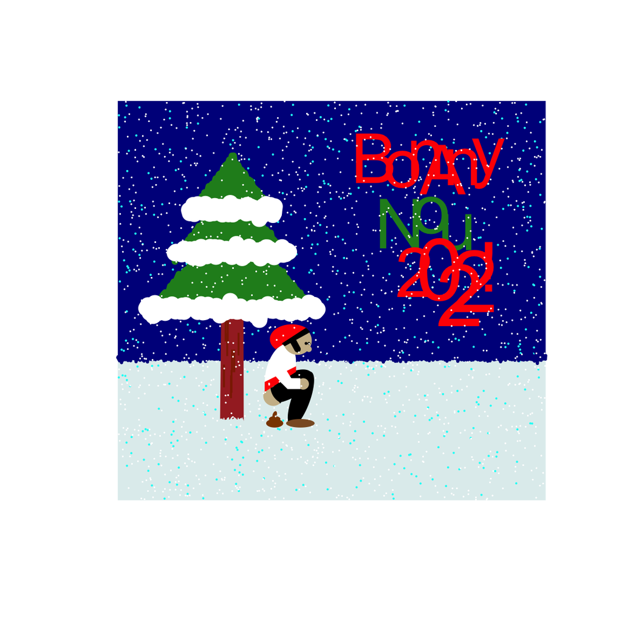

```r
xmas2021caganer()
quartz.save("caganer.png", type="png")
```

## Targeta de nadal

Per tal de fer la targeta, el més fàcil és fer-ho en un nou document a banda. A *RStudio* obriu-hi un document d’R markdown. En l’apartat del *yaml*, afegiu-hi el codi que veieu a sota. De moment no hi ha cap llibreria que dissenyi postals. Tanmateix, partirem de la llibreria *pagedown*, la qual té una plantilla per targetes de professionals. La podeu veure [aquí](https://cran.r-project.org/web/packages/pagedown/index.html). L’adaptarem al nostre cas. L’exemple següent és amb el caganer, però lògicament podeu fer servir qualsevol de les imatges que hem creat. Un petit avís: convé tenir el Google Chrome obert perquè R markdown converteix la felicitació, originalment en format *html*, en *pdf* utilitzant aquest navegador.

```r
---
name: Toni Rodon
url: www.tonirodon.cat
logo: "caganer.png"
googlefonts: ["Roboto Condensed", "Raleway"]
color: white
output: pagedown::business_card
cardwidth: 5in
knit: pagedown::chrome_print
---
```

Si la voleu adaptar, podeu retocar el CSS de la forma següent:

```r
{css}
.logo {
  display: block;
  height: 90%;
  padding: .3in 0 0;
  float: right;
}
.name {
  margin-top: .1in;
}
```

Si us ha sortit correctament, hauríeu de veure un targetó semblant al de sota.

[figure not shown]

Bon nadal a tothom!